# **Data Visualization IS 445 Final project**

*Instructor: Matthew Turk*

*Notebook by Group H* : Beatrice Lovely, Zane Inman, Manasi Karale, Zahra Malwi, Suhani Jaiswal

This data was gathered by Beatrice and a friend on the streets and sidewalks of Champaign

# *Sidewalk vs Street*

Classifying where an electric scooter is ridden based on data from Accelerometer and Gyroscope measurements

- Electric scooters are becoming ubiqitous in major cities (Lime, Spin, Voi etc)
- These scooters are only supposed to be ridden on streets or bikelanes - can we, with the help of a machine learning model, classify whether a person is riding on the sidewalk (illegal) vs street (legal)?
- An electric scooter was ridden on streets and sidewalks around Champaign
- A smartphone attached to the scooter measured Accelerometer, Gyroscope, Magnetometer

**Data Collection Setup - smartphone mounted on scooter**

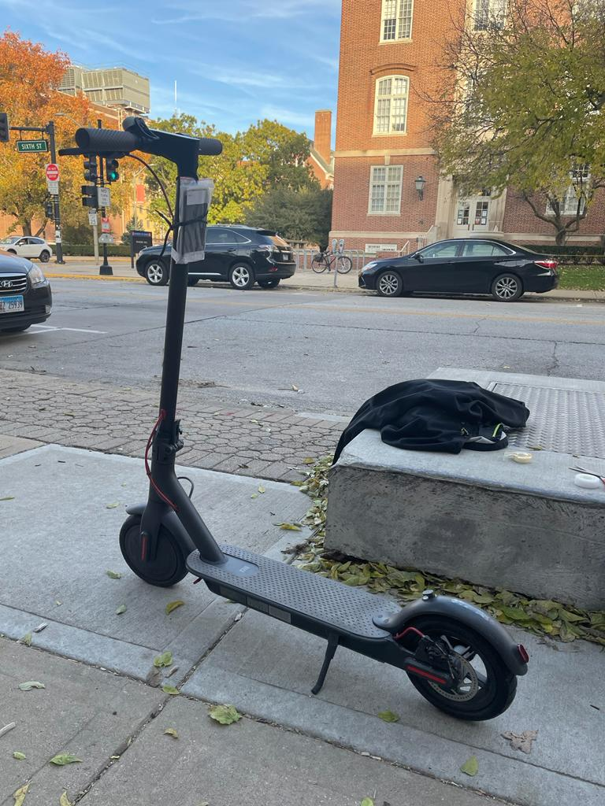

**Sidewalk on Gregory and Sixth Street**

[figure not shown]

**Street 2 : Loredo Taft Drive**

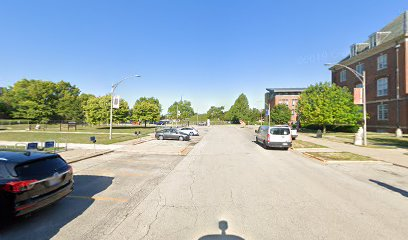

**Parameters used:**

1. **Accelerometer**; It measures linear acceleration (specified in mV/g) along one or several axis.
2. **Gyroscope**; A gyroscope measures angular velocity (specified in mV/deg/s)
3. **Magnetometer**; A magnetometer is a device that measures magnetic field or magnetic dipole moment. Magnetometers are widely used for measuring the Earth's magnetic field, in geophysical surveys, to detect magnetic anomalies of various types, and to determine the dipole moment of magnetic materials.

```
/content/gdrive/MyDrive/data-viz-project
data-viz-exploration.ipynb	  st1MedRider1NoWeight1.csv
plots				  st1MedRider1Weight1.csv
sidewalk1FastRider1NoWeight.csv   st1SlowRider1Noweight1.csv
sidewalk1FastRider1Weight.csv	  st1SlowRider1Weight1.csv
sidewalk1MedRider1Noweight.csv	  st2Fastrider1.csv
sidewalk1MedRider1Weight.csv	  st2FastRider2.csv
sidewalk1SlowRider1NoWeight.csv   st2MedRider1.csv
sidewalk1SlowRider1Weight.csv	  st2Rider2Med1.csv
sidewalkbrickRider2_1.csv	  st2Rider2Slow1.csv
sidewalkbrickRider2_2.csv	  st2Rider2Slow2.csv
sidewalkFastBWeight1.csv	  st2Rider4.csv
sidewalkFastRider2NoWeight1.csv   st2Rider5.csv
sidewalkFastRider2NoWeight2.csv   st2SlowRider1.csv
sidewalkMedRider2NoWeight1.csv	  st3Rider5.csv
sidewalkMedRider2Weight1.csv	  street1FastRider2NoWeight1.csv
sidewalkRider3.csv		  street1FastRider2Weight1.csv
sidewalkRider4.csv		  street1MedRider2NoWeight1.csv
sidewalkRider5.csv		  street1MedRider2NoWeight2.csv
sidewalkSlowRider2NoWeight1.csv   street1MedRider2weight1.csv
sidewalkSlowRider2weighttest.csv  street1Rider2NoWeight1.csv
st1FastRider1NoWeight1.csv	  street1SlowRider2NoWeight1.csv
st1Fastrider1Weight1.csv	  street1SlowRider2Weight1.csv
```

[output not shown]

```
sidewalkbrickRider2_2.csv
street1Rider2NoWeight1.csv
sidewalk1SlowRider1NoWeight.csv
st1SlowRider1Weight1.csv
st2Rider2Slow2.csv
sidewalkFastBWeight1.csv
st2Rider2Med1.csv
street1MedRider2NoWeight2.csv
st1MedRider1Weight1.csv
sidewalkRider3.csv
sidewalkFastRider2NoWeight2.csv
street1FastRider2NoWeight1.csv
st2Rider2Slow1.csv
street1MedRider2NoWeight1.csv
sidewalk1MedRider1Noweight.csv
sidewalkFastRider2NoWeight1.csv
st1FastRider1NoWeight1.csv
sidewalk1FastRider1NoWeight.csv
sidewalkMedRider2Weight1.csv
st1Fastrider1Weight1.csv
st1SlowRider1Noweight1.csv
street1MedRider2weight1.csv
sidewalk1FastRider1Weight.csv
sidewalkRider5.csv
street1SlowRider2Weight1.csv
st2Rider5.csv
st2MedRider1.csv
street1SlowRider2NoWeight1.csv
st1MedRider1NoWeight1.csv
st3Rider5.csv
sidewalk1MedRider1Weight.csv
sidewalkRider4.csv
sidewalk1SlowRider1Weight.csv
st2SlowRider1.csv
sidewalkbrickRider2_1.csv
st2Rider4.csv
street1FastRider2Weight1.csv
sidewalkSlowRider2weighttest.csv
sidewalkSlowRider2NoWeight1.csv
st2FastRider2.csv
sidewalkMedRider2NoWeight1.csv
st2Fastrider1.csv
```

Conclusion: sampling frequency is 50 Hz

## *The End Goal*

Can a machine learning model classify where the scooter was ridden based on the data, and what features would it need to do so?

If we can visualize features in the data and qualitatively see a difference - then a ML model should be able to tell the difference as well!

## Beatrice Visualizations

```
1001
```

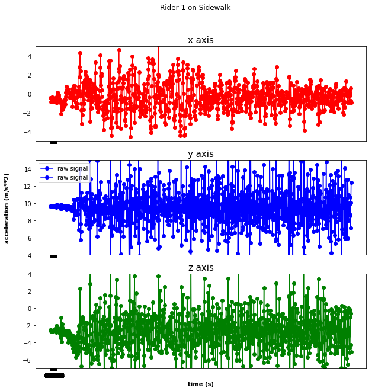

```
     filtered_x
0     -0.858290
1     -0.777990
2     -0.706487
3     -0.643436
4     -0.588490
..          ...
96    -0.042673
97    -0.025771
98    -0.033364
99     0.022325
100    0.087826

[101 rows x 1 columns]
1001
```

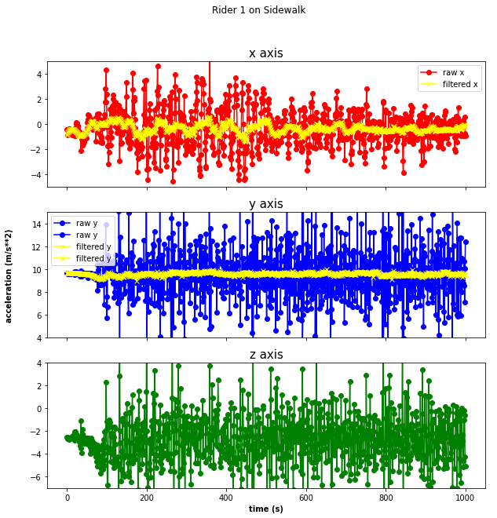

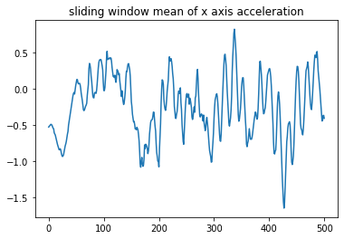

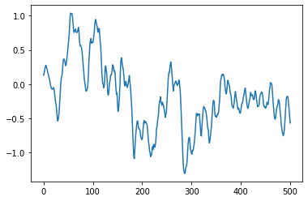

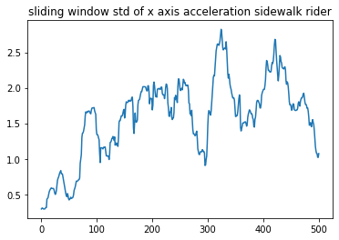

```
70.0
219.0
184.0
152.0
19.0
```

|  | mean_accl_x | mean_accl_y | mean_accl_z | mean_gyro_x | mean_gyro_y | mean_gyro_z | mean_mag_x | mean_mag_y | mean_mag_z | std_accl_x | std_accl_y | std_accl_z | std_gyro_x | std_gyro_y | std_gyro_z | std_mag_x | std_mag_y | std_mag_z | 90th_accl_x | 90th_accl_y | 90th_accl_z | 90th_gyro_x | 90th_gyro_y | 90th_gyro_z | 90th_mag_x | 90th_mag_y | 90th_mag_z | 10th_accl_x | 10th_accl_y | … |
| --- | --- | --- | --- | --- | --- | --- | --- | --- | --- | --- | --- | --- | --- | --- | --- | --- | --- | --- | --- | --- | --- | --- | --- | --- | --- | --- | --- | --- | --- | --- |
| 0 | 0.376558 | -0.002606 | -0.005624 | 0.011983 | -0.033863 | -0.092868 | -0.299830 | -0.780752 | -1.452001 | 0.878067 | 0.265967 | 0.585933 | 0.052766 | 0.230085 | 0.056715 | 0.201428 | 0.189659 | 0.088121 | 1.532120 | 0.307337 | 0.763202 | 0.074635 | 0.220162 | -0.032544 | -0.044647 | -0.491850 | -1.349074 | -0.689147 | -0.292178 | … |
| 1 | -0.058552 | -0.002043 | -0.012387 | 0.039744 | 0.095769 | -0.049463 | -0.465137 | -0.878676 | -1.387945 | 1.267043 | 0.204134 | 0.601195 | 0.091188 | 0.277229 | 0.069333 | 0.135211 | 0.208362 | 0.077520 | 1.423620 | 0.216382 | 0.719599 | 0.165942 | 0.491930 | 0.052103 | -0.271206 | -0.576670 | -1.291094 | -1.682920 | -0.253601 | … |
| 2 | 0.006872 | 0.013289 | 0.042639 | 0.004542 | 0.083924 | -0.062287 | -0.347418 | -0.817245 | -1.449055 | 0.504068 | 0.248833 | 0.447441 | 0.033139 | 0.122400 | 0.040062 | 0.145762 | 0.193387 | 0.070006 | 0.585312 | 0.344890 | 0.674266 | 0.044232 | 0.242112 | -0.010914 | -0.178455 | -0.561913 | -1.348314 | -0.635868 | -0.270773 | … |
| 3 | -0.068347 | 0.020082 | 0.086054 | 0.012313 | 0.046630 | -0.045600 | -0.413947 | -0.680191 | -1.447721 | 0.438812 | 0.224567 | 0.406842 | 0.030621 | 0.104474 | 0.030314 | 0.126587 | 0.209178 | 0.066545 | 0.405843 | 0.277387 | 0.654685 | 0.059191 | 0.160602 | -0.008651 | -0.270213 | -0.459458 | -1.358530 | -0.641695 | -0.201923 | … |
| 4 | -0.037892 | 0.012899 | 0.090230 | 0.010506 | 0.021282 | -0.064604 | -0.337942 | -0.415782 | -1.442321 | 0.633067 | 0.225893 | 0.481539 | 0.048068 | 0.166016 | 0.048668 | 0.090942 | 0.217815 | 0.072361 | 0.813689 | 0.257843 | 0.709927 | 0.072790 | 0.295882 | 0.005916 | -0.210675 | -0.179442 | -1.341055 | -0.871460 | -0.210468 | … |

Above I have actually divided data into training samples for a ML model by "chopping up" each and every data stream into windows of 75 samples each, and z-normalizing (mean 0, std 1), and computing features (mean, std, 90th percentile, 10th percentile. Below is a basic feature importance analysis, a heatmap of which features are most correlated to the label. Interestingly it is the 10th percentile of of accelerometer in y and z directions, I was expecting it to be standard deviation or something.

```
70.0
219.0
184.0
152.0
19.0
```

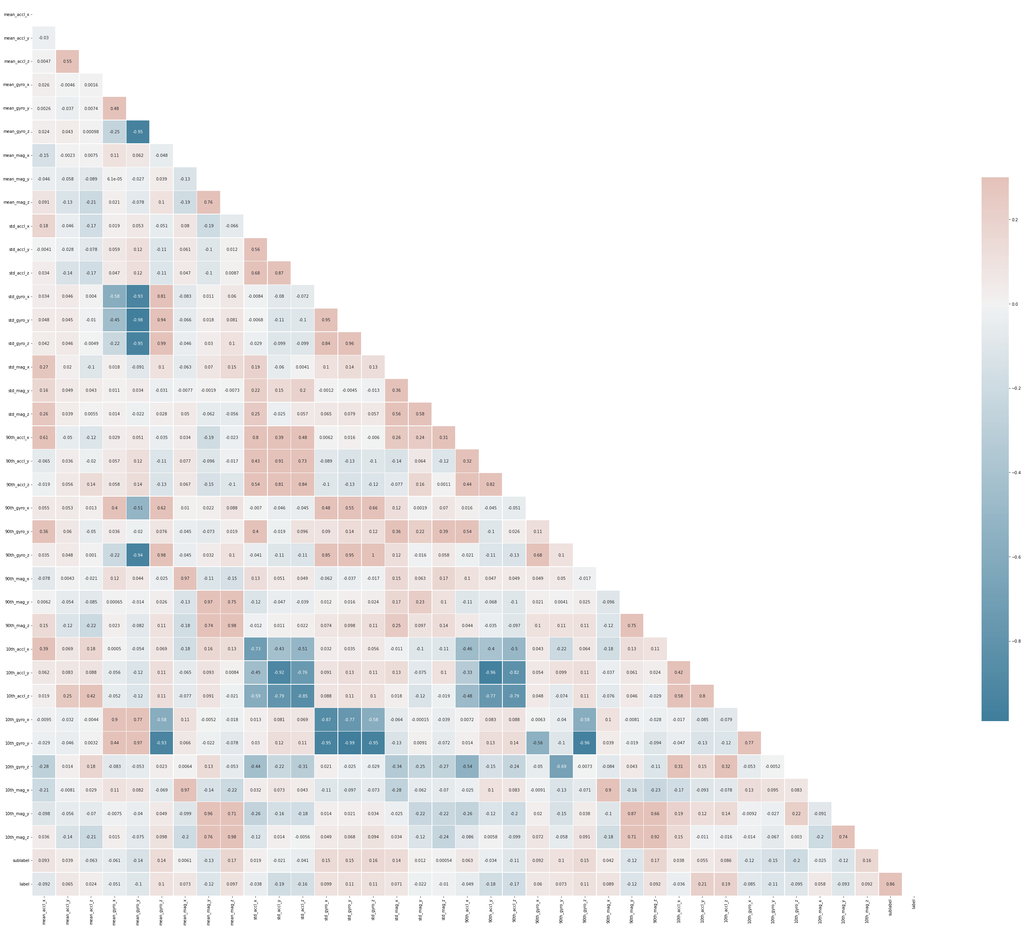

```
done!
```

# **Our Vizualization Plan:**

1. To make visualization powerful enough so that even before the data is fed to the ML model we are able to distinguish between street and sidewalk.
2. Speed of the rider and the weight carried shouldn't influence the data and hence we aggregated each sensor and each direction by using mean as its central tendency.
3. The below visualization makes it further clear:

## **Visualization by Manasi Karale:**

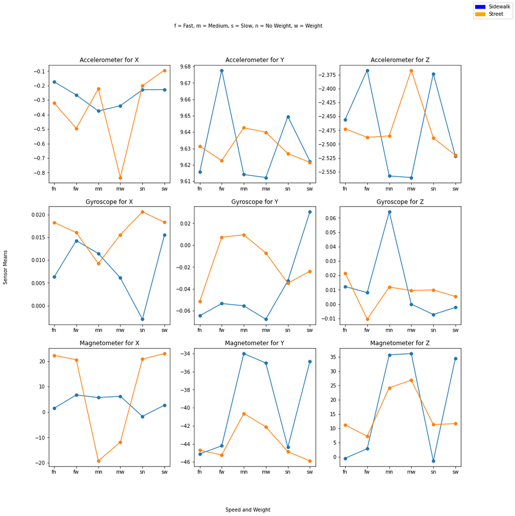

**Overview:**

The above plot is divided into 3*3 subplots. They have common X and Y axis. These subplots can be grouped such that vertically they represent same direction of sensor and horizontally they represnt sensor. The X axis has 6 main ticks -

1. fast speed + no weight rider
2. fast speed + weight rider
3. medium speed + no weight rider
4. medium speed + weight rider
5. slow speed + no weight rider
6. slow speed + weight rider

The Y axis is the mean values that we calculated for above 6 combinations. The blue line represents sidewalk values and orange line represents street values.

**Inference:**

If the blue line never overlaps with orange line then we can use that direction and sensor to provide to the ML model that will use those values to differentiate between sidewalk and street. To Note: Values not overlapping each other isn't the only requirement but we also need to have the blue line consistently over the orange line or vice a versa to confidently use the respective direction and sensor to plot the values.

```
Steps to interact with thid visualization:
    1. Choose the Sensor for your plots X, Y and Z axis
    2. Choose the Direction for your sensor
    3. Choose the File you want to compare your sensors and directions in
```

## Visualizations by Zahra Malwi

**Overview of the visualization**: This graph is a comparision between the Streets and the sidewalk in terms of their x_acceleration (i.e. when the movement is front and back) and time .Trying to see how many relevant breaks are their in the acceleartion of the scooter when moving on a sidewalk and on a street.

The breakes can tell about the difference as sidewalks are prone to have more blocks ( pedestrians / mailboxes/ dustbins/ stands,...) than the streets, as streets have more dedicated lanes mostly free of the above blocks;

**BUT it can be vice versa, too!**

[output not shown]

```
0       705074.14694
1       705074.16681
2       705074.18671
3       705074.20657
4       705074.22644
            ...
1687    705107.66112
1688    705107.68098
1689    705107.70085
1690    705107.72072
1691    705107.74058
Name: time, Length: 1692, dtype: float64
```

```
0       701631.30463
1       701631.32450
2       701631.34437
3       701631.36423
4       701631.38410
            ...
1242    701655.97934
1243    701655.99921
1244    701656.01908
1245    701656.03894
1246    701656.05881
Name: time, Length: 1247, dtype: float64
```

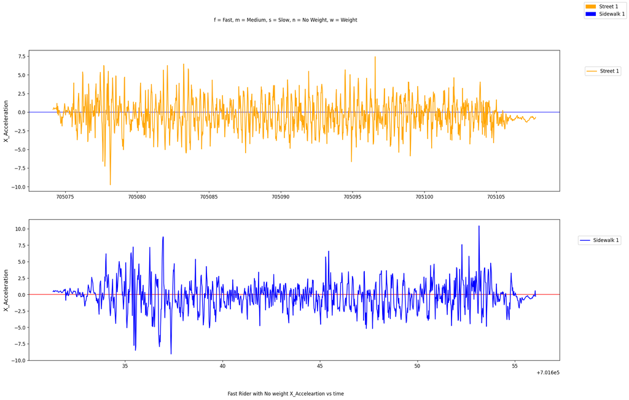

**Observation:** After carefully viewing the two graphs, it is fairly understood that the sidewalk in this case has not been obstructed much in comparision to the streets.

Deployed a quick function to check the same;

```
992
```

```
653
```

Clearly Sidewalk has less breaks;

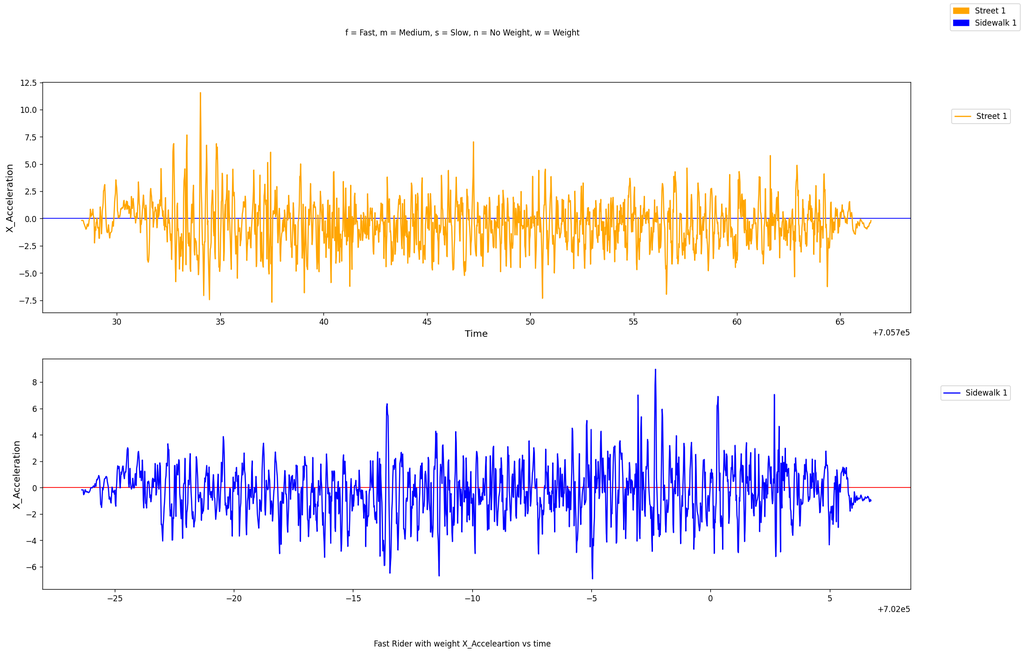

```
1173
```

```
943
```

**To have a better conclusion a subplot can be created taking all the conditions together, as this is just a prototype.**